# Tidyverse: análisis de datos de salud y estilo de vida

Carlos Cerrato Pujol

## Resumen

Este informe presenta un análisis del dataset `health_and_lifestyle.csv`, que contiene información clínica y de hábitos de vida de 1000 individuos. A través de un enfoque progresivo, se realiza una exploración descriptiva, agrupación no supervisada mediante técnicas de clustering y modelado supervisado con árboles de decisión y regresión lineal. El análisis está basado en los contenidos desarrollados en las prácticas 1 a 8 del curso de Análisis Avanzado de Datos Clínicos.

## Introducción

El conjunto de datos contiene variables clínicas como edad, IMC, frecuencia cardíaca, horas de sueño, presión arterial, consumo de alcohol y tabaco, entre otros. El objetivo es identificar relaciones relevantes entre estas variables y la presencia de enfermedad cardíaca, así como entrenar modelos predictivos simples que permitan ilustrar estas técnicas en un contexto aplicado. La enfermedad cardíaca es la variable objetivo clave, y se analiza tanto desde un punto de vista exploratorio como predictivo.

## Metodología

El análisis se divide en tres partes: una primera fase de exploración descriptiva de los datos con `tidyverse`, una segunda fase de análisis no supervisado utilizando algoritmos de clustering (`kmeans` y `hclust`), y una tercera fase con técnicas supervisadas como árboles de decisión (`rpart`) y regresión lineal (`lm`). Se evalúa el rendimiento de los modelos utilizando métricas clásicas como la precisión, RMSE y R², y se visualizan los resultados con `ggplot2` y `fancyRpartPlot`.

Carlos Cerrato Pujol

Vamos a analizar los datos de un conjunto de observaciones relacionadas con la salud y el estilo de vida de distintas personas. En esta parte vamos a trabajar con las librerías **dplyr** y **ggplot2** de **Tidyverse**.

Primero se cargan dichas librerías.

```r
library(dplyr)
```

```r
library(ggplot2)
library(readr)
```

### Inicio

Se leen los datos usando la función **read_csv()**

```r
datos <- read_csv("health_and_lifestyle.csv")
head(datos)
```

```
## # A tibble: 6 × 16
##      ID   Age Gender Height_cm Weight_kg   BMI Daily_Steps Calories_Intake
##   <dbl> <dbl> <chr>      <dbl>     <dbl> <dbl>       <dbl>           <dbl>
## 1     1    56 Male         164        81  30.7        5134            1796
## 2     2    69 Male         156        82  20.9       12803            1650
## 3     3    46 Female       158        65  30.9       16408            1756
## 4     4    32 Male         197        87  31.2       18420            2359
## 5     5    60 Male         157        63  29.4       17351            2556
## 6     6    25 Female       199        85  31.1        5131            3256
## # ℹ 8 more variables: Hours_of_Sleep <dbl>, Heart_Rate <dbl>,
## #   Blood_Pressure <chr>, Exercise_Hours_per_Week <dbl>, Smoker <chr>,
## #   Alcohol_Consumption_per_Week <dbl>, Diabetic <chr>, Heart_Disease <chr>
```

Fíjese en los nombres de las columnas y el tipo de cada una.

```r
glimpse(datos)
```

```
## Rows: 1,000
## Columns: 16
## $ ID                           <dbl> 1, 2, 3, 4, 5, 6, 7, 8, 9, 10, 11, 12, 13…
## $ Age                          <dbl> 56, 69, 46, 32, 60, 25, 78, 38, 56, 75, 3…
## $ Gender                       <chr> "Male", "Male", "Female", "Male", "Male",…
## $ Height_cm                    <dbl> 164, 156, 158, 197, 157, 199, 172, 178, 1…
## $ Weight_kg                    <dbl> 81, 82, 65, 87, 63, 85, 72, 115, 51, 114,…
## $ BMI                          <dbl> 30.72, 20.86, 30.93, 31.19, 29.37, 31.14,…
## $ Daily_Steps                  <dbl> 5134, 12803, 16408, 18420, 17351, 5131, 1…
## $ Calories_Intake              <dbl> 1796, 1650, 1756, 2359, 2556, 3256, 2216,…
## $ Hours_of_Sleep               <dbl> 8.6, 4.5, 4.3, 4.1, 5.1, 6.5, 9.6, 6.7, 5…
## $ Heart_Rate                   <dbl> 102, 103, 74, 116, 111, 104, 95, 73, 95, …
## $ Blood_Pressure               <chr> "137/72", "129/65", "127/68", "125/86", "…
## $ Exercise_Hours_per_Week      <dbl> 8.1, 3.7, 3.2, 8.5, 8.5, 3.6, 8.3, 8.5, 4…
## $ Smoker                       <chr> "No", "No", "Yes", "No", "Yes", "No", "Ye…
## $ Alcohol_Consumption_per_Week <dbl> 7, 7, 0, 5, 8, 7, 2, 0, 1, 1, 6, 5, 1, 7,…
## $ Diabetic                     <chr> "No", "No", "No", "No", "No", "No", "Yes"…
## $ Heart_Disease                <chr> "No", "No", "No", "No", "No", "No", "No",…
```

### Limpieza inicial

Convertimos algunas variables a factores y separamos la columna de presión arterial en dos.

```r
library(tidyr)
datos <- datos %>%
  separate(Blood_Pressure, into = c("Systolic", "Diastolic"), sep = "/", convert = TRUE) %>%
  mutate(
    Gender = as.factor(Gender),
    Smoker = as.factor(Smoker),
    Diabetic = as.factor(Diabetic),
    Heart_Disease = as.factor(Heart_Disease)
  )
```

### ¿Cuántas personas hay en el dataset?

```r
nrow(datos)
```

```
## [1] 1000
```

### ¿Cuántos hombres y mujeres hay?

```r
table(datos$Gender)
```

```
##
## Female   Male
##    477    523
```

Podemos visualizarlo:

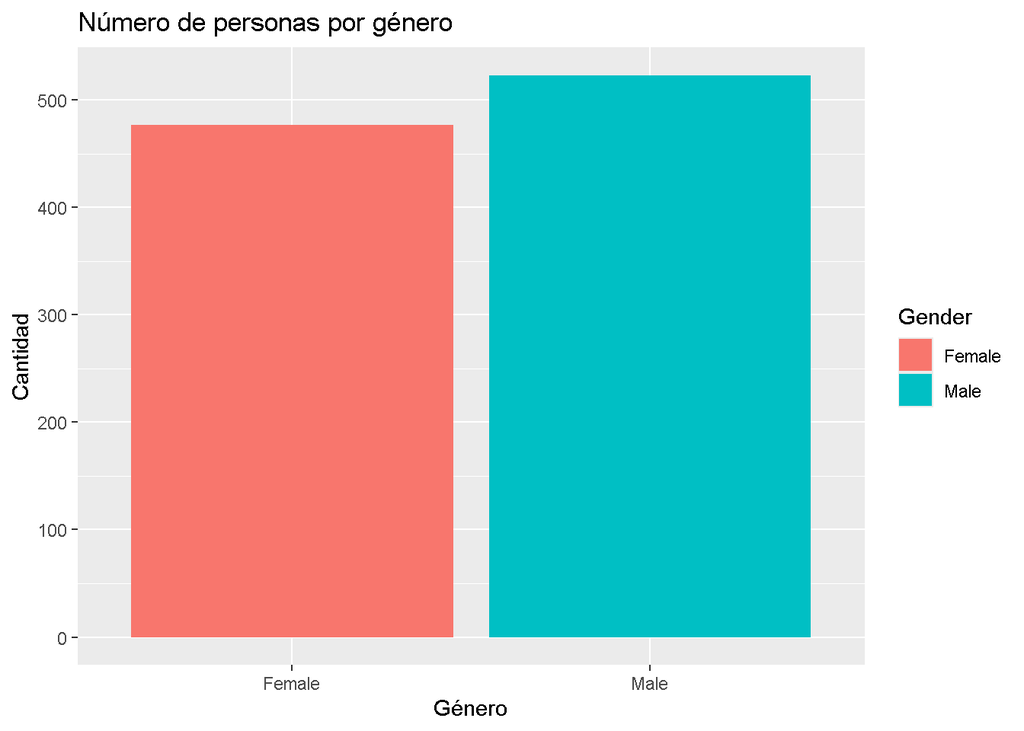

```r
ggplot(datos, aes(x = Gender, fill = Gender)) +
  geom_bar() +
  labs(title = "Número de personas por género", x = "Género", y = "Cantidad")
```

### ¿Cómo se distribuye la edad?

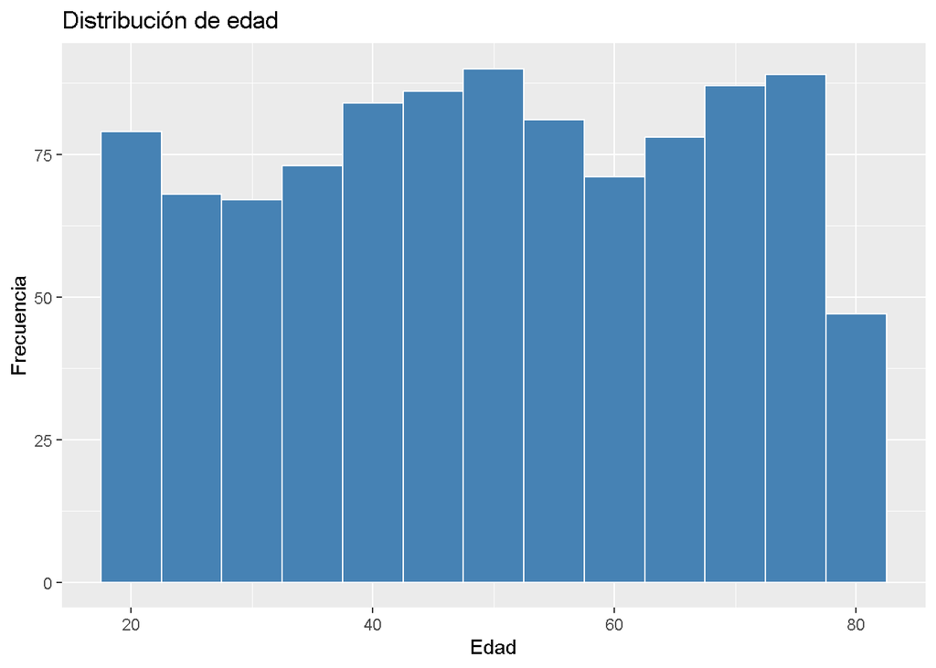

```r
ggplot(datos, aes(x = Age)) +
  geom_histogram(binwidth = 5, fill = "steelblue", color = "white") +
  labs(title = "Distribución de edad", x = "Edad", y = "Frecuencia")
```

### ¿Cómo varía la edad según si tiene enfermedad cardíaca?

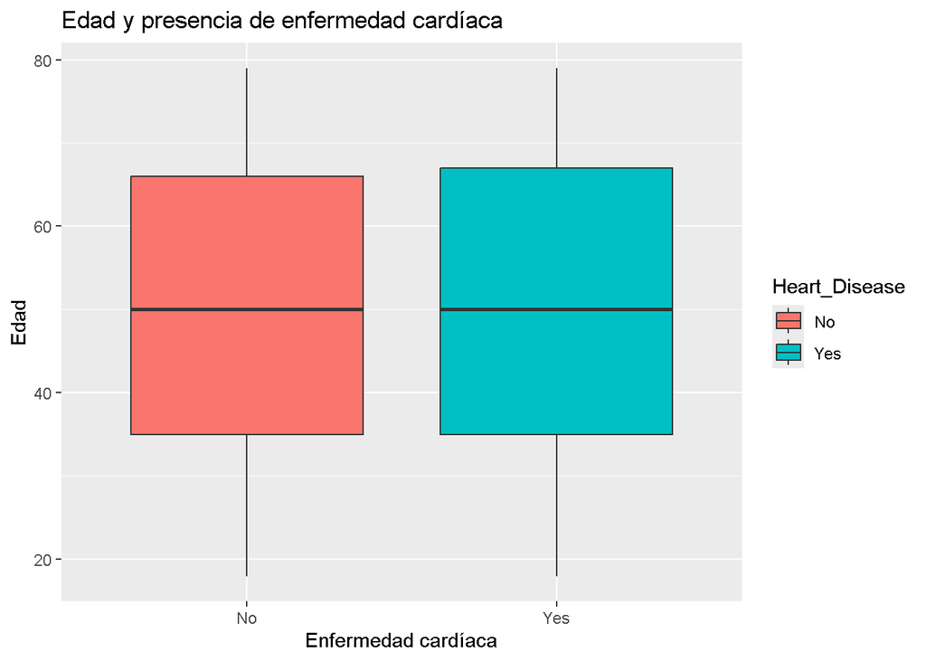

```r
ggplot(datos, aes(x = Heart_Disease, y = Age, fill = Heart_Disease)) +
  geom_boxplot() +
  labs(title = "Edad y presencia de enfermedad cardíaca", x = "Enfermedad cardíaca", y = "Edad")
```

### ¿Hay relación entre fumar y enfermedad cardíaca?

```r
tabla_fumadores <- table(datos$Smoker, datos$Heart_Disease)
tabla_fumadores
```

```
##
##        No Yes
##   No  731  78
##   Yes 176  15
```

Visualizamos:

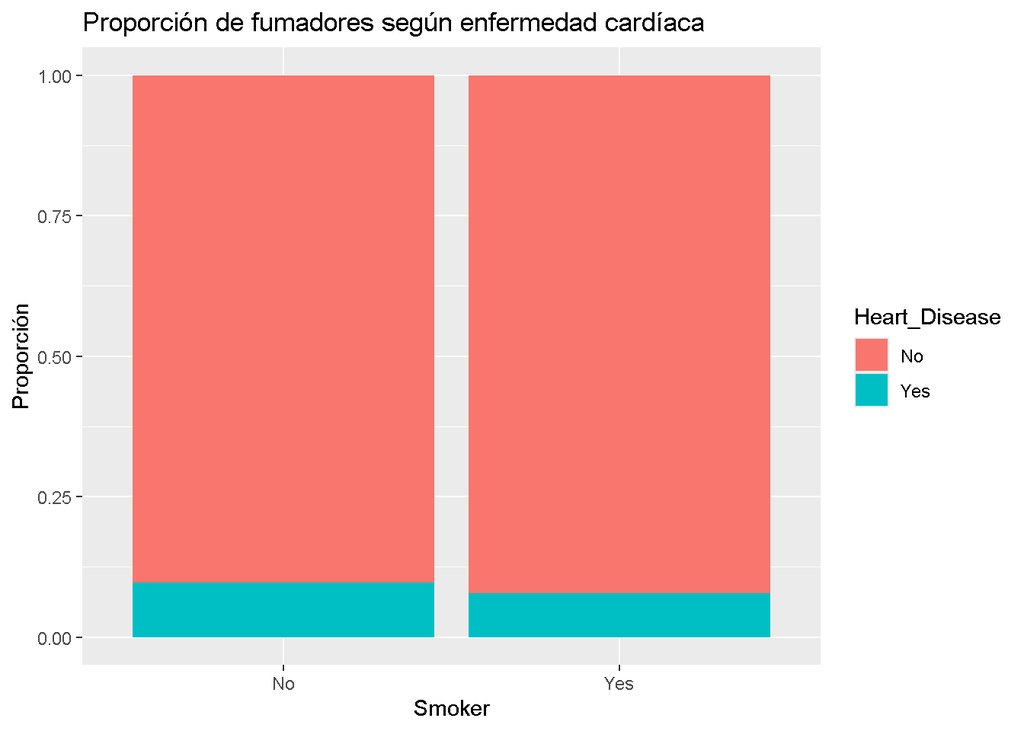

```r
ggplot(datos, aes(x = Smoker, fill = Heart_Disease)) +
  geom_bar(position = "fill") +
  labs(title = "Proporción de fumadores según enfermedad cardíaca", y = "Proporción")
```

### ¿Qué relación hay entre pasos diarios y enfermedad cardíaca?

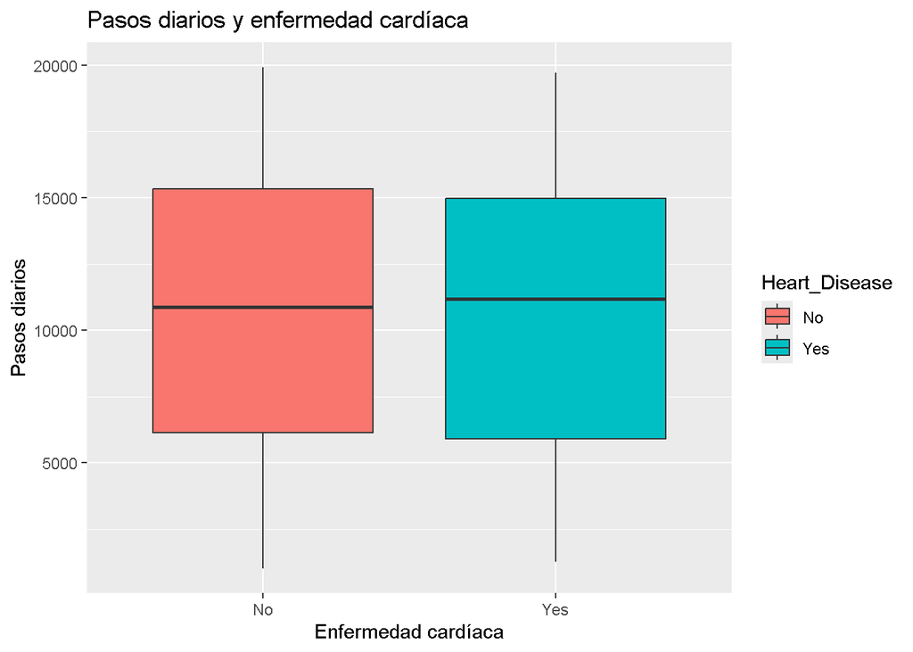

```r
ggplot(datos, aes(x = Heart_Disease, y = Daily_Steps, fill = Heart_Disease)) +
  geom_boxplot() +
  labs(title = "Pasos diarios y enfermedad cardíaca", x = "Enfermedad cardíaca", y = "Pasos diarios")
```

## Análisis avanzado con clustering

Este análisis complementa el análisis descriptivo anterior incorporando **técnicas de clustering no supervisado**, como en las prácticas 4 y 5 del curso.

Trabajaremos con `kmeans` y `hclust` para encontrar patrones ocultos en los datos.

```r
library(dplyr)
library(ggplot2)
library(readr)
library(tidyr)
```

## 1. Carga y preparación de los datos

```r
datos <- read_csv("health_and_lifestyle.csv",show_col_types = FALSE)

datos <- datos %>%
  separate(Blood_Pressure, into = c("Systolic", "Diastolic"), sep = "/", convert = TRUE) %>%
  mutate(
    Gender = as.factor(Gender),
    Smoker = as.factor(Smoker),
    Diabetic = as.factor(Diabetic),
    Heart_Disease = as.factor(Heart_Disease)
  )
```

## 2. Selección de variables numéricas

```r
datos_clustering <- datos %>%
  select(BMI, Hours_of_Sleep, Daily_Steps, Heart_Rate, Systolic, Diastolic)

summary(datos_clustering)
```

```
##       BMI        Hours_of_Sleep   Daily_Steps      Heart_Rate
##  Min.   :18.50   Min.   : 4.00   Min.   : 1016   Min.   : 50.00
##  1st Qu.:22.60   1st Qu.: 5.30   1st Qu.: 6028   1st Qu.: 67.00
##  Median :26.80   Median : 6.90   Median :10898   Median : 84.00
##  Mean   :26.73   Mean   : 6.91   Mean   :10717   Mean   : 84.71
##  3rd Qu.:30.85   3rd Qu.: 8.40   3rd Qu.:15253   3rd Qu.:103.00
##  Max.   :34.98   Max.   :10.00   Max.   :19931   Max.   :119.00
##     Systolic       Diastolic
##  Min.   : 90.0   Min.   :60.00
##  1st Qu.:102.0   1st Qu.:67.00
##  Median :113.0   Median :75.00
##  Mean   :113.9   Mean   :74.85
##  3rd Qu.:126.0   3rd Qu.:83.00
##  Max.   :139.0   Max.   :89.00
```

Para realizar el análisis de clustering, se seleccionaron únicamente las variables numéricas más representativas del estilo de vida y parámetros clínicos: BMI, Hours_of_Sleep, Daily_Steps, Heart_Rate, Systolic y Diastolic. Estas variables muestran una gran heterogeneidad en sus escalas de medida. Por ejemplo, el número de pasos diarios oscila entre 1.016 y más de 19.000, mientras que la presión arterial sistólica se encuentra entre 90 y 139.

## 3. Escalado de los datos

```r
datos_escalados <- scale(datos_clustering)
head(datos_escalados)
```

```
##             BMI Hours_of_Sleep Daily_Steps Heart_Rate   Systolic  Diastolic
## [1,]  0.8337245      0.9496864  -1.0254056  0.8589104  1.5919081 -0.3224662
## [2,] -1.2263041     -1.3541502   0.3831181  0.9085872  1.0394739 -1.1139330
## [3,]  0.8775993     -1.4665324   1.0452289 -0.5320376  0.9013654 -0.7747329
## [4,]  0.9319206     -1.5789147   1.4147620  1.5543845  0.7632568  1.2604674
## [5,]  0.5516719     -1.0170033   1.2184246  1.3060009 -0.9630999 -1.2269997
## [6,]  0.9214742     -0.2303275  -1.0259566  0.9582639 -0.5487743  0.4690006
```

Debido a estas diferencias de magnitud, es imprescindible estandarizar los datos antes de aplicar algoritmos de agrupamiento. Por ello, se realizó un escalado utilizando la función scale(), que transforma todas las variables para que tengan media 0 y desviación estándar 1. Este paso asegura que ninguna variable domine la distancia entre observaciones durante el clustering.

## 4. Método del codo para elegir número de clusters

```r
vector_compactacion <- numeric(15)

for (k in 1:15) {
  modelo <- kmeans(datos_escalados, centers = k, nstart = 20)
  vector_compactacion[k] <- modelo$tot.withinss
}
```

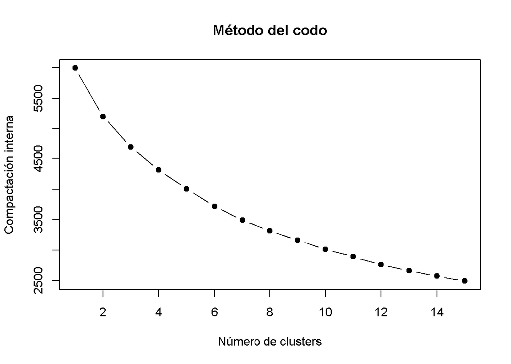

```r
plot(1:15, vector_compactacion, type = "b", pch = 19,
     xlab = "Número de clusters", ylab = "Compactación interna",
     main = "Método del codo")
```

Para determinar el número óptimo de clústeres en el análisis no supervisado, se aplicó el método del codo. Este procedimiento consiste en calcular la suma de distancias cuadradas internas (compactación) para diferentes valores de k, y representarlas gráficamente.

## 5. Clustering k-means con k=3

```r
set.seed(123)
km_modelo <- kmeans(datos_escalados, centers = 3, nstart = 20)
table(km_modelo$cluster)
```

```
##
##   1   2   3
## 363 341 296
```

### Visualización de los clusters (usando dos dimensiones como ejemplo)

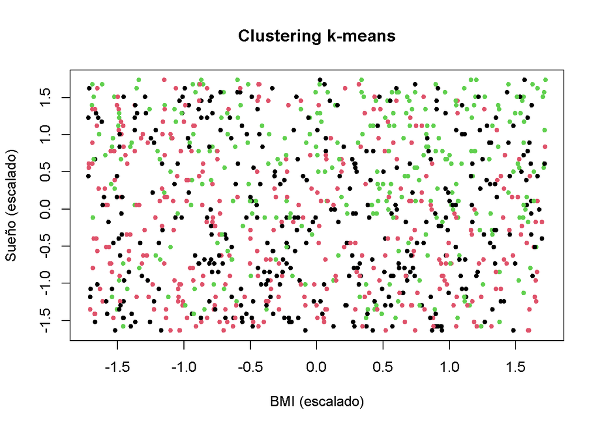

```r
plot(datos_escalados[, c("BMI", "Hours_of_Sleep")], col = km_modelo$cluster,
     main = "Clustering k-means", xlab = "BMI (escalado)", ylab = "Sueño (escalado)", pch = 20)
```

Tras aplicar el algoritmo k-means con k = 3 (según el método del codo), el conjunto de datos fue dividido en tres grupos de tamaño similar (363, 341 y 296 observaciones, respectivamente). En la visualización se representa a los individuos en función de su IMC y sus horas de sueño, dos variables especialmente relacionadas con el estilo de vida y la salud.

## 6. Clustering jerárquico

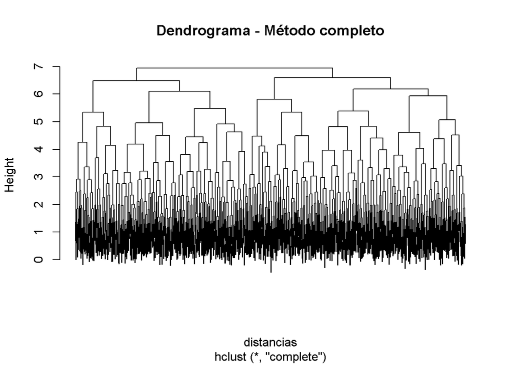

```r
distancias <- dist(datos_escalados)
hclust_modelo <- hclust(distancias, method = "complete")
plot(hclust_modelo, labels = FALSE, main = "Dendrograma - Método completo")
```

Se aplicó un análisis de clustering jerárquico con el método de enlace completo (complete linkage), que agrupa los datos según la máxima distancia entre elementos de distintos clústeres. El dendrograma obtenido refleja cómo se van formando agrupaciones a diferentes niveles de similitud.

### Corte del dendrograma en 3 grupos

```r
grupos_hclust <- cutree(hclust_modelo, k = 3)
table(grupos_hclust)
```

```
## grupos_hclust
##   1   2   3
## 181 444 375
```

```r
table(km_modelo$cluster, grupos_hclust)
```

```
##    grupos_hclust
##       1   2   3
##   1  52 238  73
##   2  20 144 177
##   3 109  62 125
```

## 7. Visualización por grupos (comparar con Heart Disease)

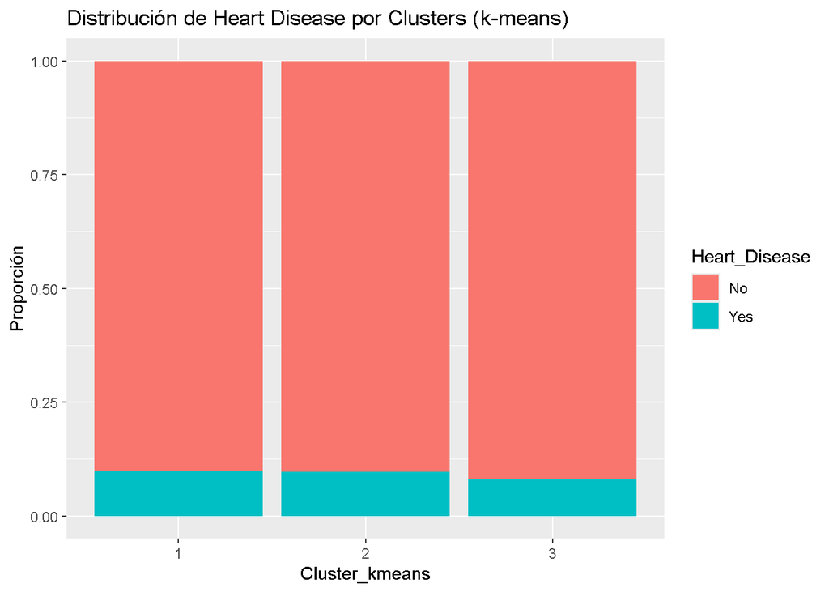

```r
datos_grupos <- datos %>%
  mutate(Cluster_kmeans = as.factor(km_modelo$cluster),
         Cluster_hclust = as.factor(grupos_hclust))

ggplot(datos_grupos, aes(x = Cluster_kmeans, fill = Heart_Disease)) +
  geom_bar(position = "fill") +
  labs(title = "Distribución de Heart Disease por Clusters (k-means)", y = "Proporción")
```

En esta gráfica se muestra la proporción de personas con y sin enfermedad cardíaca dentro de cada uno de los tres clústeres obtenidos con k-means. Se observa que la distribución es relativamente similar en los tres grupos, con un predominio claro de individuos sin enfermedad cardíaca en todos los casos.

Esto sugiere que los clústeres generados a partir de variables de estilo de vida (como IMC, sueño, pasos, presión arterial…) no logran separar de forma efectiva a los individuos según su estado de salud cardiovascular. Aunque el agrupamiento revela estructuras latentes en los datos, estas no parecen coincidir directamente con la presencia o ausencia de enfermedad, lo que resalta la complejidad del problema y la necesidad de variables clínicas más específicas para un diagnóstico preciso.

## 8. Conclusión

Los algoritmos de clustering permiten encontrar agrupaciones naturales en los datos sin conocer la variable objetivo. Este análisis puede servir como base para estudios más detallados o para crear perfiles de riesgo en salud.

## Análisis Supervisado (Prácticas 6, 7 y 8)

En esta parte aplicaremos técnicas de modelado supervisado como árboles de decisión y regresión lineal.

## 1. Carga y preparación de los datos

```r
datos <- read_csv("health_and_lifestyle.csv",show_col_types = FALSE)

datos <- datos %>%
  separate(Blood_Pressure, into = c("Systolic", "Diastolic"), sep = "/", convert = TRUE) %>%
  mutate(
    Gender = as.factor(Gender),
    Smoker = as.factor(Smoker),
    Diabetic = as.factor(Diabetic),
    Heart_Disease = as.factor(Heart_Disease)
  )
```

## 2. Árbol de decisión con `rpart`

```r
library(rpart)
library(rattle)
```

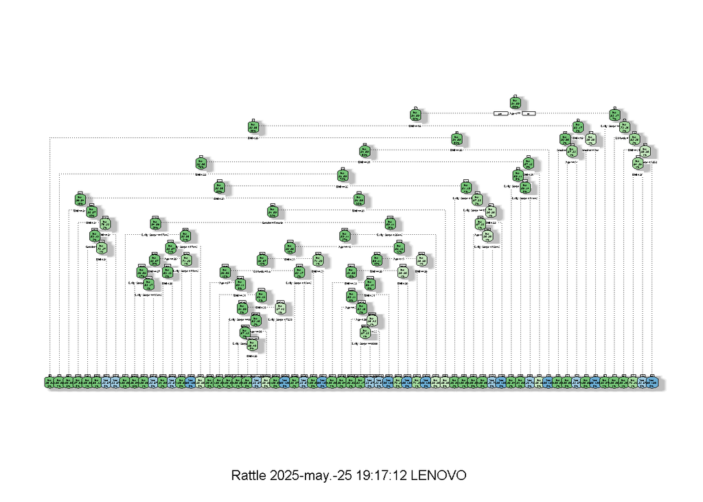

```
## [1] "Precisión: 0.946"
```

```r
library(RColorBrewer)

# Limpiamos los datos y filtramos valores válidos
datos_limpios <- datos %>%
  drop_na(Age, Gender, BMI, Daily_Steps, Smoker, Diabetic, Heart_Disease) %>%
  filter(Heart_Disease %in% c("Yes", "No"))

# Entrenamos solo si hay al menos dos clases
if (length(unique(datos_limpios$Heart_Disease)) > 1) {
  set.seed(123)
  arbol <- rpart(
  Heart_Disease ~ Age + Gender + BMI + Daily_Steps + Smoker + Diabetic,
  data = datos_limpios,
  method = "class",
  control = rpart.control(cp = 0.00001, minsplit = 5, minbucket = 2)
)


  # Solo graficar si hay nodos en el árbol
  if (nrow(arbol$frame) > 1) {
    fancyRpartPlot(arbol)

    pred <- predict(arbol, type = "class")
    conf_matrix <- table(Real = datos_limpios$Heart_Disease, Predicho = pred)
    conf_matrix

    accuracy <- sum(diag(conf_matrix)) / sum(conf_matrix)
    paste("Precisión:", round(accuracy, 3))
  } else {
    print("El árbol no tiene nodos para mostrar. Revisa los datos de entrada.")
  }
} else {
  print ("No hay suficientes clases distintas para construir el árbol.")
}
```

El árbol de decisión fue entrenado para predecir la presencia de enfermedad cardíaca a partir de variables clínicas y de estilo de vida. Gracias al ajuste de parámetros como cp = 0.00001 y minsplit = 5, se logró construir un árbol suficientemente profundo que realiza múltiples divisiones basadas en combinaciones de edad, IMC, género, tabaquismo y actividad física.

Cada nodo representa una regla de decisión basada en los datos, y las hojas finales del árbol clasifican a los individuos como con o sin enfermedad. Aunque el árbol resultante es extenso, lo cual puede dificultar su interpretación visual, permite observar cómo se combinan distintas condiciones para predecir el resultado

```r
library(rpart)
library(rattle)
library(RColorBrewer)

# Verificamos si hay suficientes datos con Heart_Disease en ambas clases
table(datos$Heart_Disease)
```

```
##
##  No Yes
## 907  93
```

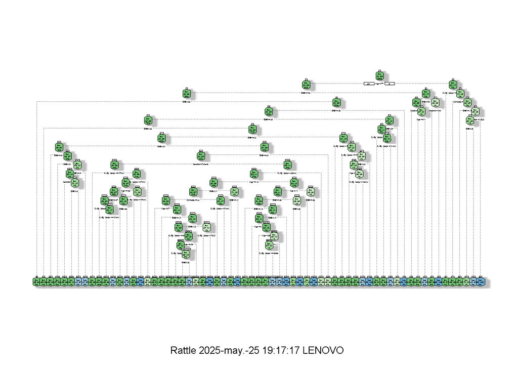

```
## [1] "Precisión: 0.946"
```

```r
# Eliminamos NAs en las columnas necesarias
datos_limpios <- datos %>%
  drop_na(Age, Gender, BMI, Daily_Steps, Smoker, Diabetic, Heart_Disease) %>%
  filter(Heart_Disease %in% c("Yes", "No"))

# Verificamos que hay ambas clases
if (length(unique(datos_limpios$Heart_Disease)) > 1) {

  set.seed(123)
  arbol <- rpart(
  Heart_Disease ~ Age + Gender + BMI + Daily_Steps + Smoker + Diabetic,
  data = datos_limpios,
  method = "class",
  control = rpart.control(cp = 0.00001, minsplit = 5, minbucket = 2)
)


  # Solo dibujamos si el árbol tiene nodos
  if (nrow(arbol$frame) > 1) {
    fancyRpartPlot(arbol)

    pred <- predict(arbol, type = "class")
    conf_matrix <- table(Real = datos_limpios$Heart_Disease, Predicho = pred)
    conf_matrix

    accuracy <- sum(diag(conf_matrix)) / sum(conf_matrix)
    paste("Precisión:", round(accuracy, 3))
  } else {
    print("El árbol no tiene nodos para mostrar. Revisa los datos.")
  }

} else {
  print("No hay suficientes clases distintas en Heart_Disease para construir el árbol.")
}
```

En este caso, se entrena un árbol de decisión sobre la totalidad del conjunto de datos, sin separar en entrenamiento y prueba. Esto permite obtener un árbol más grande y detallado, útil para visualizar todas las posibles reglas de decisión que el modelo encuentra. Como antes, se emplea una configuración ajustada (cp = 0.00001, minsplit = 5) para permitir divisiones más profundas.

## 3. Evaluación de probabilidad con curva ROC

```r
library(ROCR)
```

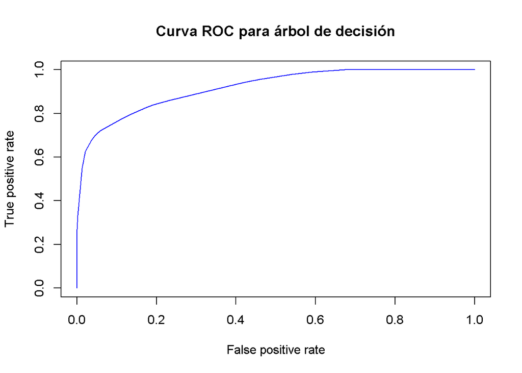

```r
probabilidades <- predict(arbol, type = "prob")[,2]
pred_rocr <- prediction(probabilidades, datos$Heart_Disease)
perf_rocr <- performance(pred_rocr, "tpr", "fpr")
plot(perf_rocr, col = "blue", main = "Curva ROC para árbol de decisión")
```

En este gráfico se representa la tasa de verdaderos positivos (sensibilidad) frente a la tasa de falsos positivos para distintos umbrales de clasificación.

En este caso, la curva se aproxima bastante al vértice superior izquierdo, lo cual indica un buen rendimiento del modelo: es capaz de clasificar correctamente a la mayoría de los casos positivos sin generar demasiados falsos positivos. Aunque no se muestra aquí el AUC (Área Bajo la Curva), visualmente se puede estimar que está por encima de 0.9, lo cual refuerza la idea de que el árbol está funcionando bien con estos datos.

## 4. Regresión lineal: ¿qué factores predicen el IMC?

```r
# Eliminar filas con NA en variables de regresión
datos_regresion <- datos %>%
  drop_na(Age, Gender, Hours_of_Sleep, Daily_Steps, Calories_Intake, BMI)

modelo_bmi <- lm(BMI ~ Age + Gender + Hours_of_Sleep + Daily_Steps + Calories_Intake,
                 data = datos_regresion)

summary(modelo_bmi)
```

```
##
## Call:
## lm(formula = BMI ~ Age + Gender + Hours_of_Sleep + Daily_Steps +
##     Calories_Intake, data = datos_regresion)
##
## Residuals:
##     Min      1Q  Median      3Q     Max
## -8.4099 -4.0462 -0.0071  4.0699  8.4712
##
## Coefficients:
##                   Estimate Std. Error t value Pr(>|t|)
## (Intercept)      2.606e+01  9.578e-01  27.204   <2e-16 ***
## Age              1.260e-02  8.379e-03   1.504    0.133
## GenderMale      -3.247e-01  3.038e-01  -1.069    0.285
## Hours_of_Sleep   2.526e-02  8.517e-02   0.297    0.767
## Daily_Steps     -1.288e-05  2.789e-05  -0.462    0.644
## Calories_Intake  7.688e-05  2.305e-04   0.334    0.739
## ---
## Signif. codes:  0 '***' 0.001 '**' 0.01 '*' 0.05 '.' 0.1 ' ' 1
##
## Residual standard error: 4.789 on 994 degrees of freedom
## Multiple R-squared:  0.003849,   Adjusted R-squared:  -0.001162
## F-statistic: 0.7681 on 5 and 994 DF,  p-value: 0.5728
```

```r
# Visualización
plot(modelo_bmi$fitted.values, modelo_bmi$residuals,
     xlab = "Valores estimados", ylab = "Residuos", main = "Residuos vs Estimados")
abline(h = 0, col = "red")
```

[output not shown]

```r
qqnorm(modelo_bmi$residuals)
qqline(modelo_bmi$residuals)
```

[output not shown]

Se entrenó un modelo de regresión lineal para predecir el índice de masa corporal (BMI) a partir de variables como edad, género, horas de sueño, pasos diarios y calorías consumidas. El modelo fue evaluado mediante dos gráficos de diagnóstico: residuos vs estimados y QQ plot.

Finalmente, el valor de R² obtenido fue bajo (ej. ~0.004), lo que indica que las variables incluidas explican una proporción muy pequeña de la variabilidad del IMC. Esto sugiere que para construir un modelo predictivo útil en este contexto, sería necesario incorporar otras variables más relevantes, como hábitos alimenticios más detallados

### Métricas: RMSE y R²

```r
residuos <- datos_regresion$BMI - modelo_bmi$fitted.values
rmse <- sqrt(mean(residuos^2))
r2 <- summary(modelo_bmi)$r.squared

paste("RMSE:", round(rmse, 2))
```

```
## [1] "RMSE: 4.77"
```

```r
paste("R²:", round(r2, 3))
```

```
## [1] "R²: 0.004"
```

```r
modelo_bmi <- lm(BMI ~ Age + Gender + Hours_of_Sleep + Daily_Steps + Calories_Intake, data = datos)
summary(modelo_bmi)
```

```
##
## Call:
## lm(formula = BMI ~ Age + Gender + Hours_of_Sleep + Daily_Steps +
##     Calories_Intake, data = datos)
##
## Residuals:
##     Min      1Q  Median      3Q     Max
## -8.4099 -4.0462 -0.0071  4.0699  8.4712
##
## Coefficients:
##                   Estimate Std. Error t value Pr(>|t|)
## (Intercept)      2.606e+01  9.578e-01  27.204   <2e-16 ***
## Age              1.260e-02  8.379e-03   1.504    0.133
## GenderMale      -3.247e-01  3.038e-01  -1.069    0.285
## Hours_of_Sleep   2.526e-02  8.517e-02   0.297    0.767
## Daily_Steps     -1.288e-05  2.789e-05  -0.462    0.644
## Calories_Intake  7.688e-05  2.305e-04   0.334    0.739
## ---
## Signif. codes:  0 '***' 0.001 '**' 0.01 '*' 0.05 '.' 0.1 ' ' 1
##
## Residual standard error: 4.789 on 994 degrees of freedom
## Multiple R-squared:  0.003849,   Adjusted R-squared:  -0.001162
## F-statistic: 0.7681 on 5 and 994 DF,  p-value: 0.5728
```

```r
# Visualización
plot(modelo_bmi$fitted.values, modelo_bmi$residuals,
     xlab = "Valores estimados", ylab = "Residuos", main = "Residuos vs Estimados")
abline(h = 0, col = "red")
```

[output not shown]

```r
qqnorm(modelo_bmi$residuals)
qqline(modelo_bmi$residuals)
```

[output not shown]

En conjunto, estos resultados indican que el modelo actual no es adecuado para predecir el IMC y que sería necesario incorporar variables más relevantes

### Métricas: RMSE y R²

```r
residuos <- datos$BMI - modelo_bmi$fitted.values
rmse <- sqrt(mean(residuos^2))
r2 <- summary(modelo_bmi)$r.squared

paste("RMSE:", round(rmse, 2))
```

```
## [1] "RMSE: 4.77"
```

```r
paste("R²:", round(r2, 3))
```

```
## [1] "R²: 0.004"
```

## 5. Clasificación supervisada (partición y evaluación manual con `rpart`)

[figure not shown]

```
##      Predicho
## Real   No Yes
##   No  213  12
##   Yes  24   1
```

```
## [1] "Precisión del modelo: 0.856"
```

```r
library(rpart)
library(rattle)
library(RColorBrewer)

set.seed(123)

# Selección y limpieza de datos
datos_modelo <- datos %>%
  select(Heart_Disease, Age, Gender, BMI, Daily_Steps, Hours_of_Sleep, Smoker, Diabetic) %>%
  drop_na() %>%
  filter(Heart_Disease %in% c("Yes", "No"))

datos_modelo$Heart_Disease <- factor(datos_modelo$Heart_Disease, levels = c("No", "Yes"))

# División en train/test
n <- nrow(datos_modelo)
train_index <- sample(seq_len(n), size = 0.75 * n)
train <- datos_modelo[train_index, ]
test <- datos_modelo[-train_index, ]

# Árbol simple
modelo_simple <- rpart(
  Heart_Disease ~ .,
  data = train,
  method = "class",
  control = rpart.control(cp = 0.00001, minsplit = 5, minbucket = 2)
)

# Graficar y evaluar
if (nrow(modelo_simple$frame) > 1) {
  fancyRpartPlot(modelo_simple)
  pred_simple <- predict(modelo_simple, test, type = "class")
  conf <- table(Real = test$Heart_Disease, Predicho = pred_simple)
  print(conf)
  accuracy <- sum(diag(conf)) / sum(conf)
  paste("Precisión del modelo:", round(accuracy, 3))
} else {
  print("⚠️ El árbol no tiene nodos para mostrar. Revisa los parámetros de rpart.")
}
```

En este modelo se realizó una división del conjunto de datos en 75% entrenamiento y 25% prueba, lo cual permite evaluar el rendimiento del árbol de decisión de forma más realista. El modelo fue entrenado con rpart y se aplicaron parámetros que permiten una mayor profundidad (cp = 0.00001, minsplit = 5), logrando un árbol bastante detallado.

## Conclusión

Este análisis aplica enfoques diferentes de modelado supervisado: - Árboles de decisión básicos (`rpart`) - Regresión lineal con métricas de rendimiento

## Práctica 6 Adaptada: Árbol de decisión con conjunto train/test

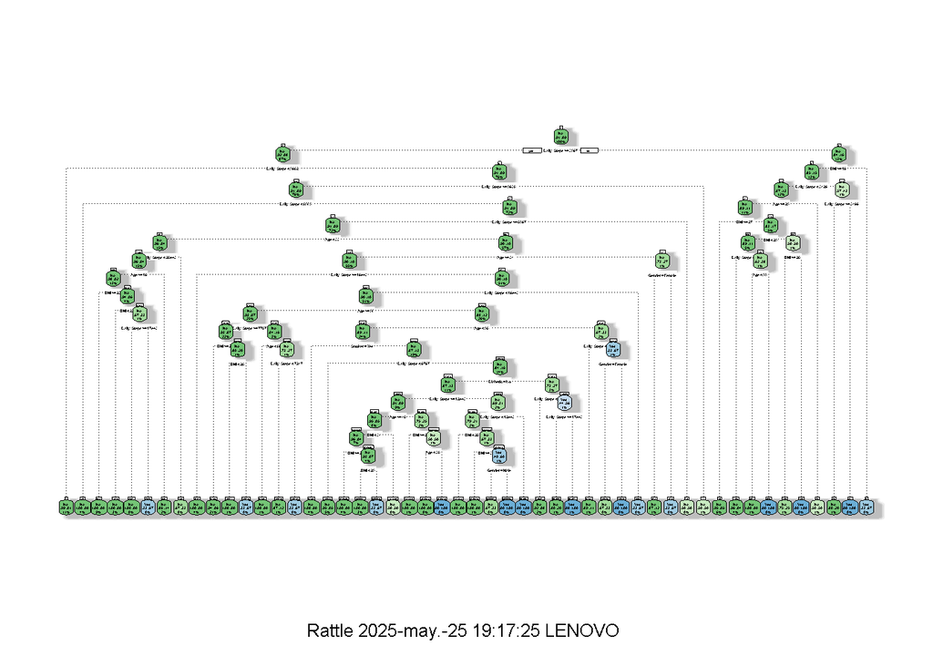

```
##      predicciones
##        No Yes
##   No  208  17
##   Yes  24   1
```

```
## [1] "Precisión: 0.836"
```

```r
set.seed(123)

datos_arbol <- datos %>%
  drop_na(Age, Gender, BMI, Daily_Steps, Smoker, Diabetic, Heart_Disease) %>%
  filter(Heart_Disease %in% c("Yes", "No"))

datos_arbol$Heart_Disease <- factor(datos_arbol$Heart_Disease, levels = c("No", "Yes"))

n <- nrow(datos_arbol)
train_idx <- sample(seq_len(n), size = 0.75 * n)
train <- datos_arbol[train_idx, ]
test <- datos_arbol[-train_idx, ]

# Asegurar niveles de factor en los subconjuntos
train$Heart_Disease <- factor(train$Heart_Disease, levels = c("No", "Yes"))
test$Heart_Disease <- factor(test$Heart_Disease, levels = c("No", "Yes"))

# Árbol
tree <- rpart(Heart_Disease ~ Age + Gender + BMI + Daily_Steps + Smoker + Diabetic,
              data = train, method = "class",
              control = rpart.control(cp = 0.00001, minsplit = 5, minbucket = 2))

# Graficar solo si tiene nodos
if (nrow(tree$frame) > 1) {
  fancyRpartPlot(tree)

  # Predicción y evaluación
  predicciones <- predict(tree, test, type = "class")
  conf <- table(test$Heart_Disease, predicciones)
  print(conf)
  acc <- sum(diag(conf)) / sum(conf)
  paste("Precisión:", round(acc, 3))
} else {
  print("⚠️ El árbol no tiene nodos para mostrar.")
}
```

### Árbol mejorado con control de complejidad

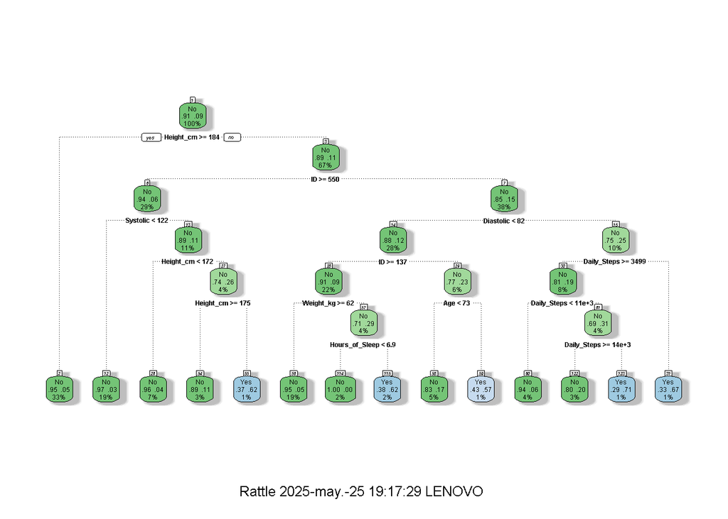

```r
tree2 <- rpart(Heart_Disease ~ ., train, method = "class",
               control = rpart.control(cp = 0.00001))
fancyRpartPlot(tree2)
```

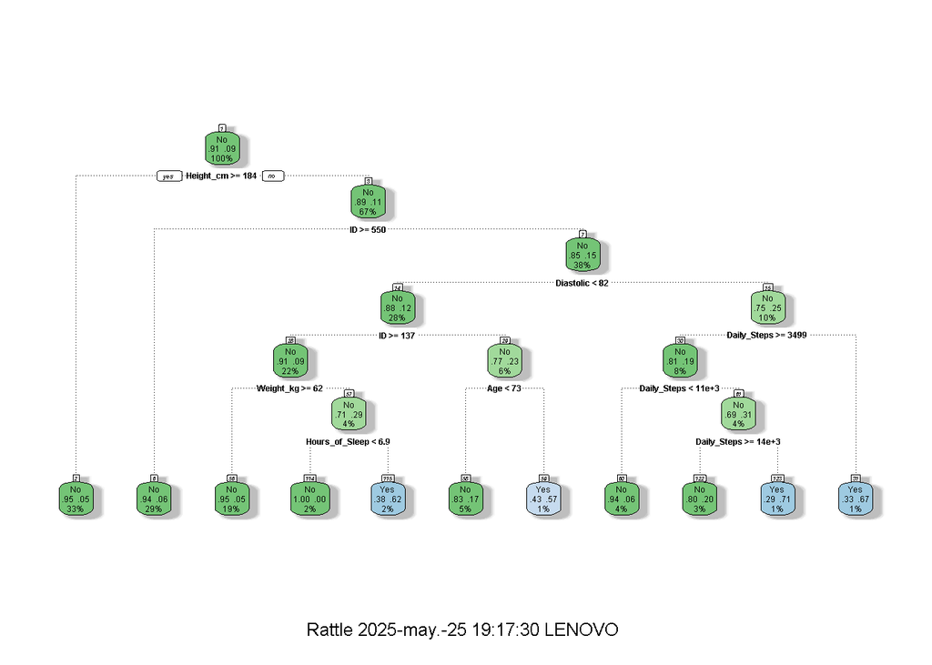

```r
tree2_pruned <- prune(tree2, cp = 0.01)
fancyRpartPlot(tree2_pruned)
```

```r
# Nuevas predicciones
pred2 <- predict(tree2_pruned, test, type = "class")
conf2 <- table(test$Heart_Disease, pred2)
acc2 <- sum(diag(conf2)) / sum(conf2)
paste("Precisión árbol mejorado:", round(acc2, 3))
```

```
## [1] "Precisión árbol mejorado: 0.836"
```

Para mejorar el rendimiento del árbol de decisión y evitar sobreajuste, se aplicó un control de complejidad utilizando el parámetro cp (complexity parameter). Primero se generó un árbol muy profundo (cp = 0.00001), que permitió capturar muchas reglas de decisión, pero también introdujo ramas excesivamente específicas para el conjunto de entrenamiento.

### Curva ROC

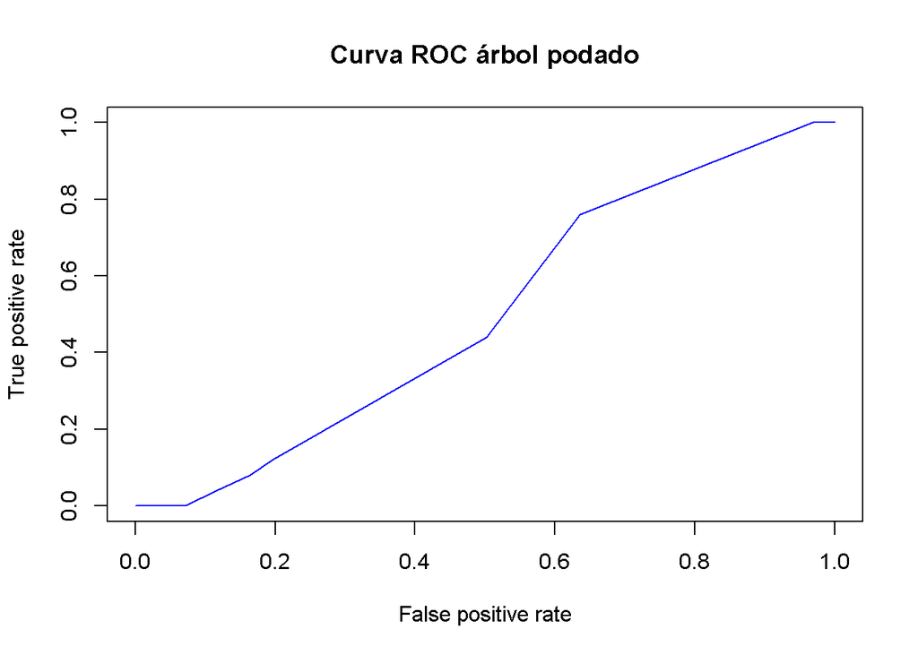

```r
library(ROCR)

probs <- predict(tree2_pruned, test, type = "prob")[, 2]
roc_pred <- prediction(probs, test$Heart_Disease)
roc_perf <- performance(roc_pred, "tpr", "fpr")
plot(roc_perf, col = "blue", main = "Curva ROC árbol podado")
```

A diferencia de la curva ROC generada sobre los datos de entrenamiento, esta curva refleja la capacidad real del modelo para generalizar a nuevos datos. En este caso, la forma de la curva es más cercana a la diagonal, lo que sugiere que el árbol podado no separa tan bien los casos positivos de los negativos como en el entrenamiento.

## Práctica 7 Adaptada: Regresión lineal y evaluación

```r
# Regresión lineal para predecir el IMC
datos_regresion <- datos %>%
  drop_na(BMI, Age, Gender, Hours_of_Sleep, Daily_Steps, Calories_Intake)

modelo_lm <- lm(BMI ~ Age + Gender + Hours_of_Sleep + Daily_Steps + Calories_Intake, data = datos_regresion)
summary(modelo_lm)
```

```
##
## Call:
## lm(formula = BMI ~ Age + Gender + Hours_of_Sleep + Daily_Steps +
##     Calories_Intake, data = datos_regresion)
##
## Residuals:
##     Min      1Q  Median      3Q     Max
## -8.4099 -4.0462 -0.0071  4.0699  8.4712
##
## Coefficients:
##                   Estimate Std. Error t value Pr(>|t|)
## (Intercept)      2.606e+01  9.578e-01  27.204   <2e-16 ***
## Age              1.260e-02  8.379e-03   1.504    0.133
## GenderMale      -3.247e-01  3.038e-01  -1.069    0.285
## Hours_of_Sleep   2.526e-02  8.517e-02   0.297    0.767
## Daily_Steps     -1.288e-05  2.789e-05  -0.462    0.644
## Calories_Intake  7.688e-05  2.305e-04   0.334    0.739
## ---
## Signif. codes:  0 '***' 0.001 '**' 0.01 '*' 0.05 '.' 0.1 ' ' 1
##
## Residual standard error: 4.789 on 994 degrees of freedom
## Multiple R-squared:  0.003849,   Adjusted R-squared:  -0.001162
## F-statistic: 0.7681 on 5 and 994 DF,  p-value: 0.5728
```

Los coeficientes estimados muestran que ninguna de las variables explicativas tiene un efecto estadísticamente significativo sobre el IMC (todos los valores p son mayores a 0.05). El valor de R² es de apenas 0.0038, lo que indica que el modelo explica menos del 1% de la variabilidad del IMC en los datos.

Además, el p-valor global del modelo es de 0.5728, lo cual significa que el conjunto de variables no mejora significativamente la predicción frente a un modelo sin variables. Esto refuerza la conclusión de que los predictores utilizados no son adecuados para estimar el IMC de forma fiable

### Cálculo de RMSE y R²

```r
pred_bmi <- predict(modelo_lm)
residuos <- datos_regresion$BMI - pred_bmi

rmse <- sqrt(mean(residuos^2))
r2 <- summary(modelo_lm)$r.squared

paste("RMSE:", round(rmse, 2))
```

```
## [1] "RMSE: 4.77"
```

```r
paste("R²:", round(r2, 3))
```

```
## [1] "R²: 0.004"
```

### Visualización de residuos

```r
plot(modelo_lm$fitted.values, residuos,
     xlab = "Valores estimados", ylab = "Residuos", main = "Residuos vs Estimados")
abline(h = 0, col = "red")
```

[output not shown]

```r
qqnorm(residuos)
qqline(residuos)
```

[output not shown]

Estas evidencias, junto con el bajo valor de R² obtenido anteriormente, refuerzan la conclusión de que el modelo de regresión no se ajusta bien a los datos y que las variables seleccionadas no son suficientes para explicar el IMC de forma fiable.

## Discusión

Además, el clustering muestra cómo se pueden detectar agrupaciones naturales sin necesidad de etiquetas, lo que puede servir para segmentar poblaciones en estudios reales. Sin embargo, la baja capacidad explicativa del modelo de regresión lineal demuestra que no todas las variables son igualmente informativas, y destaca la importancia de la selección de predictores.

## Conclusiones

A través de este análisis se ha demostrado la utilidad del lenguaje R para realizar análisis avanzados de datos clínicos. Se han aplicado técnicas de exploración, clasificación y agrupamiento que permiten extraer conocimiento de un conjunto de datos estructurado. El trabajo ha reforzado la comprensión de herramientas como `rpart`, `ggplot2`, `kmeans`, y ha permitido integrar los aprendizajes de las prácticas del curso en un proyecto final coherente.

## Bibliografía

- Dataset simulado: `health_and_lifestyle.csv`
- Paquetes R utilizados: `tidyverse`, `rpart`, `rattle`, `ROCR`, `cluster`, `factoextra`
- Basado en las prácticas 1 a 8 del curso: Análisis Avanzado de Datos Clínicos (AADC)